# Shrinkage and Hyperparameter Tuning

Yunting Chiu

2021-06-14

This week we will talk about **shrinkage** and **hyperparameter** tuning.

We will use the `Hitters` data set from the `ISLR` library. It can be loaded using the following code

The vast majority of variables are numerical, with the remainder being factors.

```r
library(tidyverse)
library(tidymodels)
library(ISLR)
data("Hitters")
Hitters %>%
  str()
```

```
## 'data.frame':    322 obs. of  20 variables:
##  $ AtBat    : int  293 315 479 496 321 594 185 298 323 401 ...
##  $ Hits     : int  66 81 130 141 87 169 37 73 81 92 ...
##  $ HmRun    : int  1 7 18 20 10 4 1 0 6 17 ...
##  $ Runs     : int  30 24 66 65 39 74 23 24 26 49 ...
##  $ RBI      : int  29 38 72 78 42 51 8 24 32 66 ...
##  $ Walks    : int  14 39 76 37 30 35 21 7 8 65 ...
##  $ Years    : int  1 14 3 11 2 11 2 3 2 13 ...
##  $ CAtBat   : int  293 3449 1624 5628 396 4408 214 509 341 5206 ...
##  $ CHits    : int  66 835 457 1575 101 1133 42 108 86 1332 ...
##  $ CHmRun   : int  1 69 63 225 12 19 1 0 6 253 ...
##  $ CRuns    : int  30 321 224 828 48 501 30 41 32 784 ...
##  $ CRBI     : int  29 414 266 838 46 336 9 37 34 890 ...
##  $ CWalks   : int  14 375 263 354 33 194 24 12 8 866 ...
##  $ League   : Factor w/ 2 levels "A","N": 1 2 1 2 2 1 2 1 2 1 ...
##  $ Division : Factor w/ 2 levels "E","W": 1 2 2 1 1 2 1 2 2 1 ...
##  $ PutOuts  : int  446 632 880 200 805 282 76 121 143 0 ...
##  $ Assists  : int  33 43 82 11 40 421 127 283 290 0 ...
##  $ Errors   : int  20 10 14 3 4 25 7 9 19 0 ...
##  $ Salary   : num  NA 475 480 500 91.5 750 70 100 75 1100 ...
##  $ NewLeague: Factor w/ 2 levels "A","N": 1 2 1 2 2 1 1 1 2 1 ...
```

Remove all rows where the salary is `NA` and split the data into testing and training data sets.

```r
Hitters %>%
  filter(!is.na(Salary)) -> Hitters_narm

set.seed(1234)
Hitters_split <- initial_split(Hitters_narm)
Hitters_train <- training(Hitters_split)
Hitters_test <- testing(Hitters_split)
```

# No Penalty in L2 regularization

1. Use `linear_reg()` with `mixture = 0` to specify a **ridge regression model**.
- `mixture = 0` is L2 regularization. That is, ridge.
- `mixture = 1` is L1 regularization. That is, lasso.

Let’s set the `penalty` to `0` to see what happens.

```r
ridge_spec0 <- linear_reg(mixture = 0, penalty = 0) %>%
  set_mode("regression") %>%
  set_engine("glmnet")

ridge_spec0
```

```
## Linear Regression Model Specification (regression)
##
## Main Arguments:
##   penalty = 0
##   mixture = 0
##
## Computational engine: glmnet
```

Put in our ingredients and get a recipe. Because ridge regression is scale sensitive, we must ensure that the variables are on the same scale by using `step_normalize(all_predictors())`.

```r
ridge_rec <- recipe(Salary ~ ., data = Hitters_train) %>%
  step_novel(all_nominal_predictors()) %>% # Novel Factor Levels
  step_dummy(all_nominal_predictors()) %>%
  step_zv(all_predictors()) %>% # remove variables that contain only a single value
  step_normalize(all_predictors()) # center and scale each column

ridge_rec
```

```
## Data Recipe
##
## Inputs:
##
##       role #variables
##    outcome          1
##  predictor         19
##
## Operations:
##
## Novel factor level assignment for all_nominal_predictors()
## Dummy variables from all_nominal_predictors()
## Zero variance filter on all_predictors()
## Centering and scaling for all_predictors()
```

2. Fit the model on the data and inspect the model. What do you see?

```r
ridge_wf0 <- workflow() %>%
  add_model(ridge_spec0) %>%
  add_recipe(ridge_rec)
```

```r
ridge_fit0 <- fit(ridge_wf0, data = Hitters_train)

ridge_fit0 %>% tidy()
```

```
## # A tibble: 20 x 3
##    term        estimate penalty
##    <chr>          <dbl>   <dbl>
##  1 (Intercept)    569.        0
##  2 AtBat         -122.        0
##  3 Hits           118.        0
##  4 HmRun          -23.7       0
##  5 Runs            23.4       0
##  6 RBI             12.9       0
##  7 Walks          105.        0
##  8 Years          -58.6       0
##  9 CAtBat         -11.7       0
## 10 CHits          103.        0
## 11 CHmRun          63.7       0
## 12 CRuns          121.        0
## 13 CRBI           103.        0
## 14 CWalks        -110.        0
## 15 PutOuts         69.9       0
## 16 Assists         31.5       0
## 17 Errors         -16.5       0
## 18 League_N        25.9       0
## 19 Division_W     -55.4       0
## 20 NewLeague_N    -17.2       0
```

3. Try to predict using this model. What are your output?

If $\lambda = 0$ we don’t have any penalization so we still get the standard OLS estimates. A high root mean squared error indicates that the model may predict the incorrect answer.

```r
augment(ridge_fit0, new_data = Hitters_test) %>%
  rmse(truth = Salary, estimate = .pred)
```

```
## # A tibble: 1 x 3
##   .metric .estimator .estimate
##   <chr>   <chr>          <dbl>
## 1 rmse    standard        228.
```

The plot shows we can try to optimize the penalty term. That is, tuning the hyperparameter in the ridge regression model.

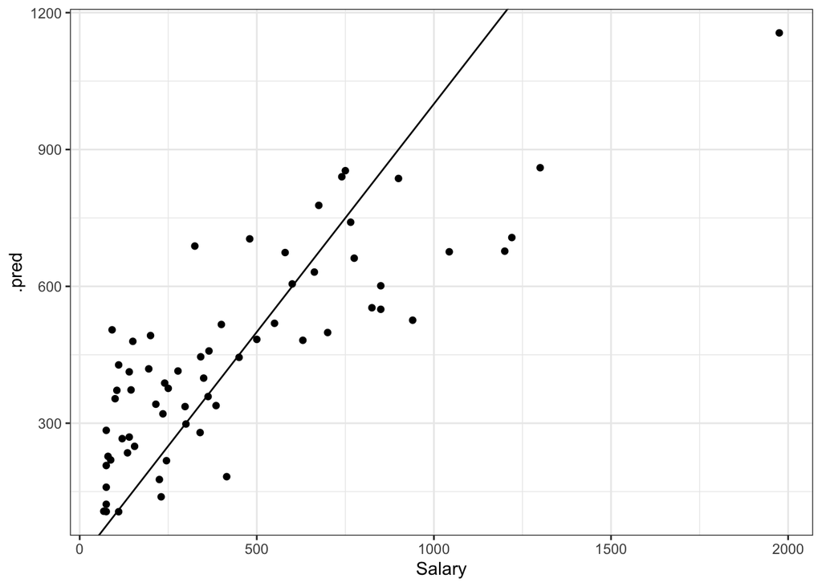

```r
augment(ridge_fit0, new_data = Hitters_test) %>%
  ggplot(aes(Salary, .pred)) +
  geom_abline(slope = 1, intercept = 0) +
  geom_point() +
  theme_bw()
```

# Hyperparameter Tuning

4. Use {tune} to setup hyperparameter tuning to determine the right amount of regularization.

Now, we set `penalty = tune()` in order to find the best hyperparameter

```r
ridge_spec <- linear_reg(mixture = 0, penalty = tune()) %>%
  set_mode("regression") %>%
  set_engine("glmnet")
```

Look at the output below, the main arguments show `penalty = tune()`. Because the hyperparameter will be automatically turning.

```r
ridge_wf <- workflow() %>%
  add_model(ridge_spec) %>%
  add_recipe(ridge_rec)
ridge_wf
```

```
## ══ Workflow ════════════════════════════════════════════════════════════════════
## Preprocessor: Recipe
## Model: linear_reg()
##
## ── Preprocessor ────────────────────────────────────────────────────────────────
## 4 Recipe Steps
##
## • step_novel()
## • step_dummy()
## • step_zv()
## • step_normalize()
##
## ── Model ───────────────────────────────────────────────────────────────────────
## Linear Regression Model Specification (regression)
##
## Main Arguments:
##   penalty = tune()
##   mixture = 0
##
## Computational engine: glmnet
```

Create the Cross-Validation term in order to use in the following `tune_grid()` session, the number of default folds is 10.

```r
set.seed(123)
Hitters_fold <- vfold_cv(Hitters_train)
```

```r
# penalty_grid <- grid_regular(list(p1 = threshold(), p2 = threshold()), levels = 10, size = 100)
# grid_max_entropy()
#penalty_grid %>%
  #ggplot(aes(p1, p2)) +
  # geom_point()
# grid_max_entropy: try to not have overlapping parts
penalty_grid <- grid_regular(penalty(range = c(0, 5)), levels = 100)
```

Show the penalty values with descending order

```r
penalty_grid %>%
  arrange(desc(penalty))
```

```
## # A tibble: 100 x 1
##    penalty
##      <dbl>
##  1 100000
##  2  89022.
##  3  79248.
##  4  70548.
##  5  62803.
##  6  55908.
##  7  49770.
##  8  44306.
##  9  39442.
## 10  35112.
## # … with 90 more rows
```

```r
tune_res <- tune_grid(
  object = ridge_wf,
  resamples = Hitters_fold,
  grid = penalty_grid) # control = control_grid(verbose = TRUE): fitting model one by one
tune_res
```

```
## # Tuning results
## # 10-fold cross-validation
## # A tibble: 10 x 4
##    splits           id     .metrics           .notes
##    <list>           <chr>  <list>             <list>
##  1 <split [178/20]> Fold01 <tibble [200 × 5]> <tibble [0 × 1]>
##  2 <split [178/20]> Fold02 <tibble [200 × 5]> <tibble [0 × 1]>
##  3 <split [178/20]> Fold03 <tibble [200 × 5]> <tibble [0 × 1]>
##  4 <split [178/20]> Fold04 <tibble [200 × 5]> <tibble [0 × 1]>
##  5 <split [178/20]> Fold05 <tibble [200 × 5]> <tibble [0 × 1]>
##  6 <split [178/20]> Fold06 <tibble [200 × 5]> <tibble [0 × 1]>
##  7 <split [178/20]> Fold07 <tibble [200 × 5]> <tibble [0 × 1]>
##  8 <split [178/20]> Fold08 <tibble [200 × 5]> <tibble [0 × 1]>
##  9 <split [179/19]> Fold09 <tibble [200 × 5]> <tibble [0 × 1]>
## 10 <split [179/19]> Fold10 <tibble [200 × 5]> <tibble [0 × 1]>
```

Display the each penalty on rmse and rsq, respectively.

```r
tune_res %>%
  collect_metrics()
```

```
## # A tibble: 200 x 7
##    penalty .metric .estimator    mean     n std_err .config
##      <dbl> <chr>   <chr>        <dbl> <int>   <dbl> <chr>
##  1    1    rmse    standard   360.       10 35.8    Preprocessor1_Model001
##  2    1    rsq     standard     0.415    10  0.0533 Preprocessor1_Model001
##  3    1.12 rmse    standard   360.       10 35.8    Preprocessor1_Model002
##  4    1.12 rsq     standard     0.415    10  0.0533 Preprocessor1_Model002
##  5    1.26 rmse    standard   360.       10 35.8    Preprocessor1_Model003
##  6    1.26 rsq     standard     0.415    10  0.0533 Preprocessor1_Model003
##  7    1.42 rmse    standard   360.       10 35.8    Preprocessor1_Model004
##  8    1.42 rsq     standard     0.415    10  0.0533 Preprocessor1_Model004
##  9    1.59 rmse    standard   360.       10 35.8    Preprocessor1_Model005
## 10    1.59 rsq     standard     0.415    10  0.0533 Preprocessor1_Model005
## # … with 190 more rows
```

Display the best five rmse value of penalty

```r
tune_res %>%
  show_best(metric = "rmse")
```

```
## # A tibble: 5 x 7
##   penalty .metric .estimator  mean     n std_err .config
##     <dbl> <chr>   <chr>      <dbl> <int>   <dbl> <chr>
## 1    335. rmse    standard    358.    10    37.9 Preprocessor1_Model051
## 2    298. rmse    standard    358.    10    37.9 Preprocessor1_Model050
## 3    266. rmse    standard    358.    10    37.9 Preprocessor1_Model049
## 4    376. rmse    standard    358.    10    38.0 Preprocessor1_Model052
## 5    236. rmse    standard    358.    10    37.8 Preprocessor1_Model048
```

# Visualize the RMSE and RSQ

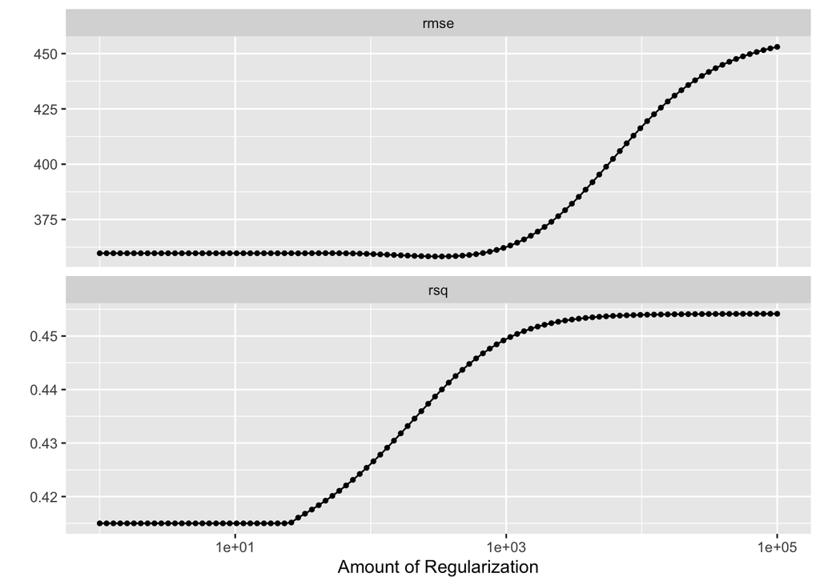

```r
tune_res %>%
  autoplot()
```

```r
best_rmse <- select_best(tune_res, metric = "rmse")
best_rmse
```

```
## # A tibble: 1 x 2
##   penalty .config
##     <dbl> <chr>
## 1    335. Preprocessor1_Model051
```

# Fit the Best Hyperparameter

5. Fit the best model. How does your parameter estimates look like?

```r
ridge_final <- finalize_workflow(ridge_wf, best_rmse)
```

```r
ridge_final_fit <- fit(ridge_final, data = Hitters_train)

ridge_fit0 %>% summary()
```

```
##         Length Class      Mode
## pre     2      stage_pre  list
## fit     2      stage_fit  list
## post    1      stage_post list
## trained 1      -none-     logical
```

```r
ridge_final_fit %>% tidy()
```

```
## # A tibble: 20 x 3
##    term        estimate penalty
##    <chr>          <dbl>   <dbl>
##  1 (Intercept)   569.      335.
##  2 AtBat           7.19    335.
##  3 Hits           34.5     335.
##  4 HmRun          -3.63    335.
##  5 Runs           25.1     335.
##  6 RBI            19.2     335.
##  7 Walks          47.0     335.
##  8 Years           3.73    335.
##  9 CAtBat         25.9     335.
## 10 CHits          39.4     335.
## 11 CHmRun         35.2     335.
## 12 CRuns          40.3     335.
## 13 CRBI           42.7     335.
## 14 CWalks         11.6     335.
## 15 PutOuts        43.0     335.
## 16 Assists         7.03    335.
## 17 Errors         -4.81    335.
## 18 League_N        8.49    335.
## 19 Division_W    -34.7     335.
## 20 NewLeague_N     1.02    335.
```

When we tuned the hyperparameter in the model, the rmse does not show a obvious reduction when compared to the `penalty = 0`’s rmse: 228. This means that tuning the hyperparameter will not work in this model.

```r
augment(ridge_final_fit, new_data = Hitters_test) %>%
  rmse(truth = Salary, estimate = .pred)
```

```
## # A tibble: 1 x 3
##   .metric .estimator .estimate
##   <chr>   <chr>          <dbl>
## 1 rmse    standard        239.
```

Because the data points are still separated, this method does not provide much benefit for weight loss.

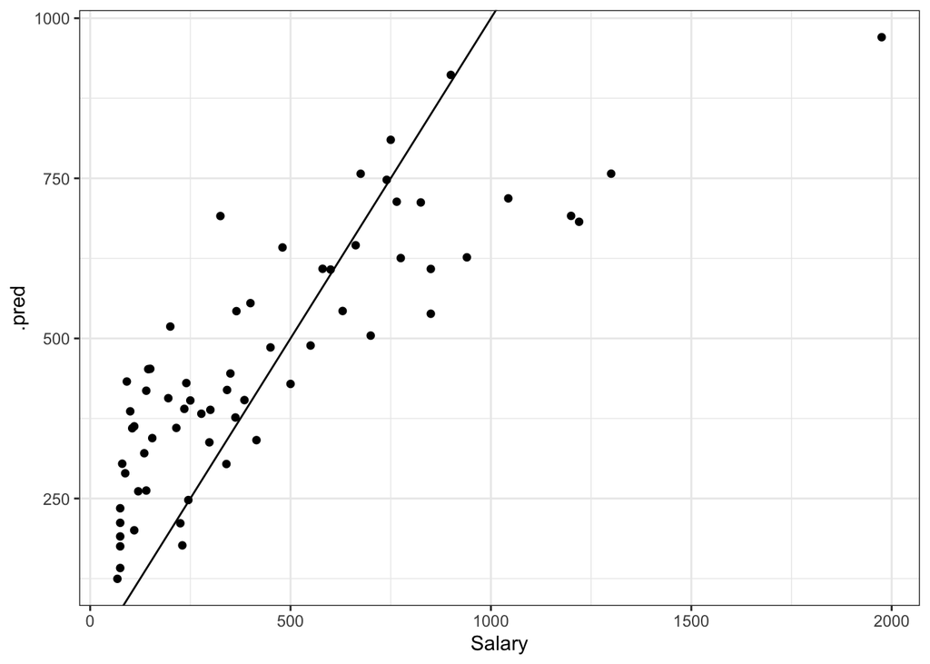

```r
augment(ridge_final_fit, new_data = Hitters_test) %>%
  ggplot(aes(Salary, .pred)) +
  geom_abline(slope = 1, intercept = 0) +
  geom_point() +
  theme_bw()
```

# Comapre Residual

```r
augment(ridge_final_fit, new_data = Hitters_test) %>%
  mutate(RS = (Salary-.pred)^2) %>%
  select(RS)
```

```
## # A tibble: 65 x 1
##         RS
##      <dbl>
##  1  26254.
##  2 116410.
##  3  13400.
##  4  36214.
##  5   2656.
##  6    131.
##  7  21090.
##  8 258741.
##  9   6745.
## 10   5451.
## # … with 55 more rows
```

```r
augment(ridge_fit0, new_data = Hitters_test) %>%
  mutate(RS = (Salary-.pred)^2) %>%
  select(RS)
```

```
## # A tibble: 65 x 1
##         RS
##      <dbl>
##  1  50222.
##  2 170727.
##  3   2234.
##  4  21880.
##  5    595.
##  6   4028.
##  7  16033.
##  8 273343.
##  9  10518.
## 10  53933.
## # … with 55 more rows
```

# References

- https://emilhvitfeldt.github.io/ISLR-tidymodels-labs/linear-model-selection-and-regularization.html
- https://www.tmwr.org/grid-search.html